# Raport bazy danych

Kacper Haczkiewicz, Maria Kwintal, Laura Nowak, Paweł Nowak

Styczeń 2025

# 1 Wstęp

Firma Wombat Grylls sp. z o.o. specjalizuje się w organizowaniu wycieczek do miast, które odegrały istotną rolę w historii matematyki. W ramach naszego projektu opracowujemy kompletną bazę danych wspierającą organizację takich wyjazdów. Umożliwia ona przechowywanie i zarządzanie informacjami o miastach, atrakcjach turystycznych, klientach, pracownikach, a także transakcjach i organizowanych wycieczkach. Projekt ten pozwala na efektywne zarządzanie danymi i umożliwia szybkie tworzenie analiz wspierających decyzje biznesowe.

# 2 Opis danych

Nasza baza danych składa się z następujących tabel:

1. **Miasta** - Zawiera informacje o miastach, w których żyli znani matematycy. Przechowywane dane obejmują nazwę miasta, cenę wyjazdu, długość wycieczki oraz nazwisko matematyka związanego z tym miejscem.
2. **Atrakcje w mieście** - Przechowuje dane o atrakcjach turystycznych dostępnych w poszczególnych miastach.
3. **Wycieczki** - Obejmuje informacje o organizowanych wyjazdach, takie jak data rozpoczęcia, czy wycieczka się odbyła oraz do jakiego miasta była skierowana.
4. **Klienci** - Zawiera dane osobowe klientów, takie jak imię, nazwisko, adres e-mail, status studenta oraz przysługujące im zniżki.
5. **Pracownicy** - Informacje o pracownikach zaangażowanych w organizację wycieczek, w tym ich stanowisko oraz dane kontaktowe.
6. **Transakcje** - Rejestruje informacje o zakupach wycieczek przez klientów, takie jak kwota, data transakcji oraz powiązane wycieczki.
7. **Relacje bliskości** - Łączy klientów z ich bliskimi osobami, co umożliwia rejestrację grupowych rezerwacji.
8. **Wynagrodzenie** - Przechowuje informacje o stawkach wynagrodzenia dziennego przypisanych do poszczególnych stanowisk.
9. **Wycieczki i pracownicy** - Łączy wycieczki z przypisanymi do nich pracownikami, co pozwala na tworzenie grafików i zarządzanie zasobami ludzkimi.

# 3 Znaczenie projektu

Baza danych opracowana w ramach tego projektu pełni kluczową rolę w działalności firmy. Umożliwia:

- Efektywne zarządzanie danymi o wycieczkach, klientach i pracownikach.
- Tworzenie analiz sprzedaży i popularności wycieczek.
- Planowanie logistyki oraz monitorowanie wyników finansowych.

# 4 Wyniki

## 4.1 Wynik 1

Na początek warto sprawdzić, które wycieczki cieszą się największym zainteresowaniem.

| Liczba osób zainteresowanych na poszczególne wycieczki Wycieczka | Liczba osób zainteresowanych na poszczególne wycieczki Liczba osób zainteresowanych |
| --- | --- |
| Jedburgh | 407 |
| Princeton | 365 |
| Alexandria | 363 |
| Descartes | 351 |
| Cambridge | 341 |
| Halle | 294 |

Jak widać, najpopularniejszą wycieczką jest Jedburgh. Liczba zainteresowanych nią osób to: 407

## 4.2 Wynik 2

Kolejnym krokiem jest porównanie kosztów i zysków dla najpopularniejszych wycieczek:

| Opłacalne Wycieczki Wycieczka | Opłacalne Wycieczki Liczba Wycieczek | Opłacalne Wycieczki Koszt | Opłacalne Wycieczki Przychód | Opłacalne Wycieczki Zysk |
| --- | --- | --- | --- | --- |
| Princeton | 6 | 87600 | 1331550 | 1243950 |
| Oslo | 5 | 72000 | 580419 | 508419 |
| Jedburgh | 6 | 81600 | 480130 | 398530 |
| Descartes | 7 | 85200 | 412380 | 327180 |
| Paryz | 4 | 62400 | 389000 | 326600 |
| London | 4 | 67200 | 367494 | 300294 |
| Syracuse | 4 | 56400 | 347282 | 290882 |
| Alexandria | 4 | 56400 | 325660 | 269260 |
| Basel | 4 | 44400 | 258910 | 214510 |
| Nancy | 4 | 44400 | 243355 | 198955 |
| Cambridge | 6 | 87600 | 271470 | 183870 |
| Stockholm | 2 | 25200 | 193152 | 167952 |
| Halle | 5 | 66000 | 192186 | 126186 |
| Clermont-Ferrand | 2 | 25200 | 121710 | 96510 |
| Samos | 2 | 25200 | 117195 | 91995 |
| Erlangen | 3 | 31200 | 112200 | 81000 |
| Beaumont-en-Auge | 2 | 20800 | 82854 | 62054 |
| Braunschweig | 2 | 16800 | 41760 | 24960 |

Łatwo widać, że największe zyski mają te wycieczki: Princeton. Zysk tych wycieczek wynosi: 1243950, a przychód: 1331550.

| Nieopłacalne Wycieczki Wycieczka | Nieopłacalne Wycieczki Liczba Wycieczek | Nieopłacalne Wycieczki Koszt | Nieopłacalne Wycieczki Przychód | Nieopłacalne Wycieczki Zysk |
| --- | --- | --- | --- | --- |
| Wroclaw | 3 | 28800 | 27666 | -1134 |

Nieopłacale wycieczki są do takich miast jak: Wroclaw.

## 4.3 Wynik 3

Należy zwrócić uwagę na to, po której wycieczce nasi klienci wracają najchętniej.

| Liczba osób powracających na nasze wycieczki Wycieczka | Liczba osób powracających na nasze wycieczki Liczba klientów | Liczba osób powracających na nasze wycieczki Liczba powracających | Liczba osób powracających na nasze wycieczki Procent |
| --- | --- | --- | --- |
| Descartes | 351 | 173 | 49.29 |
| Wroclaw | 119 | 57 | 47.90 |
| Braunschweig | 90 | 42 | 46.67 |
| Cambridge | 341 | 152 | 44.57 |
| Syracuse | 230 | 101 | 43.91 |
| Alexandria | 215 | 94 | 43.72 |
| Basel | 191 | 83 | 43.46 |
| Samos | 99 | 42 | 42.42 |
| Paryz | 244 | 101 | 41.39 |
| Halle | 265 | 108 | 40.75 |
| Clermont-Ferrand | 101 | 41 | 40.59 |
| Nancy | 182 | 73 | 40.11 |
| Stockholm | 100 | 40 | 40.00 |
| Jedburgh | 319 | 127 | 39.81 |
| Erlangen | 175 | 69 | 39.43 |
| Oslo | 270 | 106 | 39.26 |
| Beaumont-en-Auge | 116 | 44 | 37.93 |
| Princeton | 333 | 126 | 37.84 |
| London | 202 | 74 | 36.63 |

Jak wynika z tabeli, najwięcej (49.29%) klientów powraca do miast: Descartes.

Najmniej osób (36.63%) ponownie wybiera się do London.

## 4.4 Wynik 4

W poniższej tabeli można zobaczyć, do jakich dwóch miejsc najchętniej wybierają się nasi klienci.

| Najpopularniejsze kombinacje dwóch wycieczek odwiedzanych przez tych samych klientów Wycieczka pierwsza | Najpopularniejsze kombinacje dwóch wycieczek odwiedzanych przez tych samych klientów Wycieczka druga | Najpopularniejsze kombinacje dwóch wycieczek odwiedzanych przez tych samych klientów Liczba klientów |
| --- | --- | --- |
| Princeton | Jedburgh | 19 |
| Descartes | Jedburgh | 17 |
| Cambridge | Jedburgh | 15 |
| Descartes | Cambridge | 14 |
| Jedburgh | Descartes | 13 |
| Syracuse | Jedburgh | 13 |
| Descartes | Descartes | 12 |
| Jedburgh | Cambridge | 12 |
| Princeton | Alexandria | 11 |
| Halle | Cambridge | 11 |

Najpopularniejsze kombinacje dwóch wycieczek to:  
Princeton i Jedburgh.  
Każdą z tych kombinacji wybrało 19 klientów.

## 4.5 Wynik 5

Analizując nasze dane z obecnych lat możemy wywnioskować, że średnia liczba osób bliskich, która uczestniczyła w naszych wycieczkach wynosi: 4.

# 5 Wykresy

## 5.1 Wykres 1

Poniższy wykres przedstawia ilość klientów w określonych miesiącach.

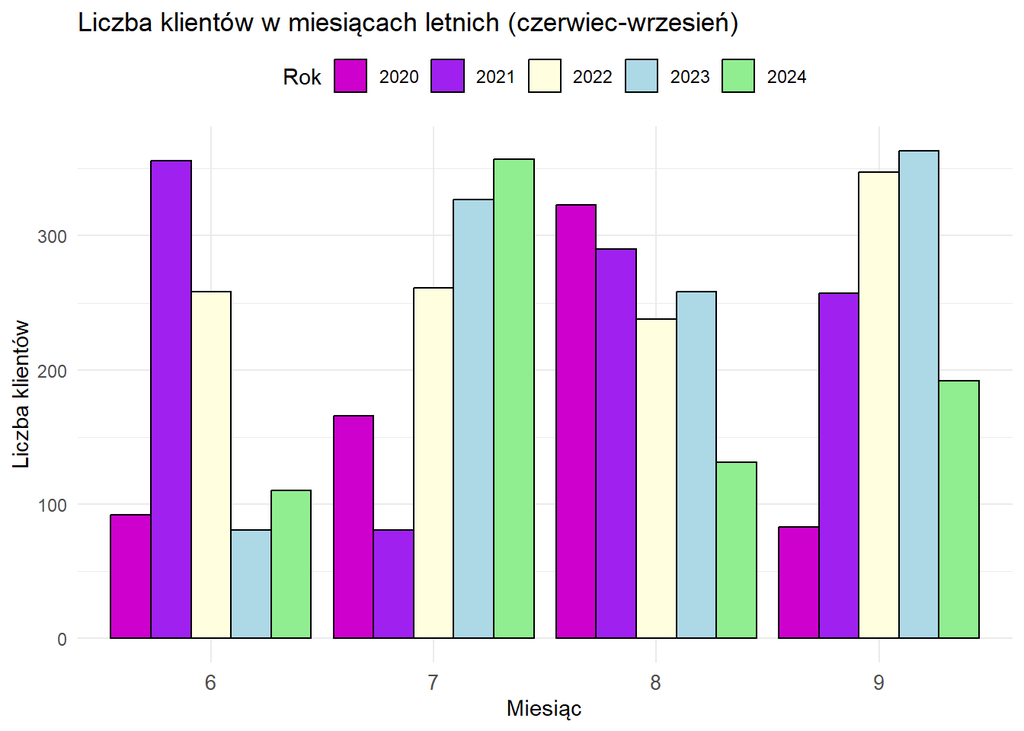

Patrząc na wykres można zayważyć, że: Trendy liczby klientów są niestabilne. Liczba klientów w miesiącach letnich wykazuje wahania w różnych latach.

## 5.2 Wykres 2

Poniżej widać udział procentowy w miastach.

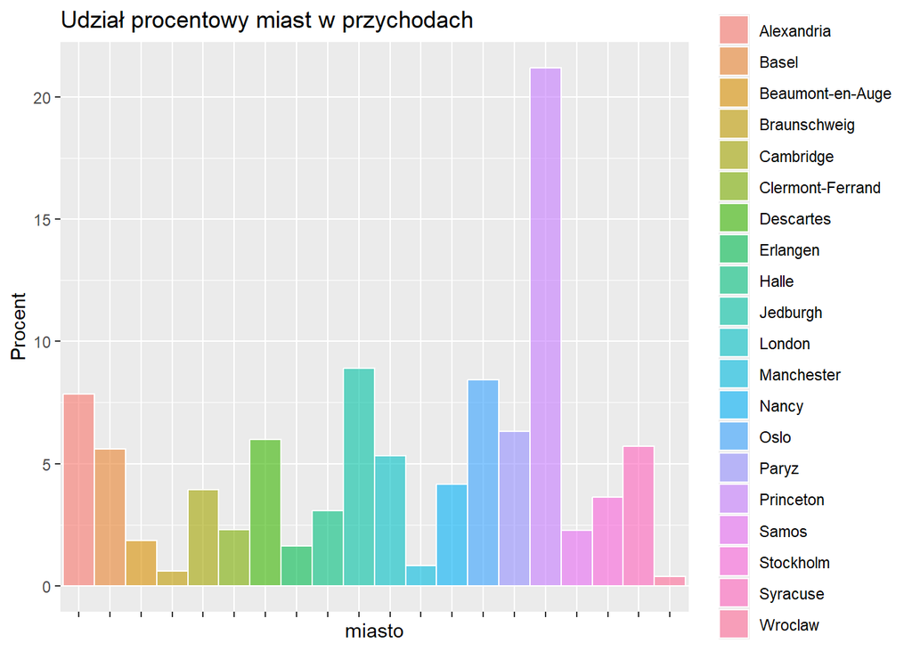

## 5.3 Wykres 3

Poniższy wykres słupkowy przedstawia, ile klientów średnio wybiera się na wycieczkę.

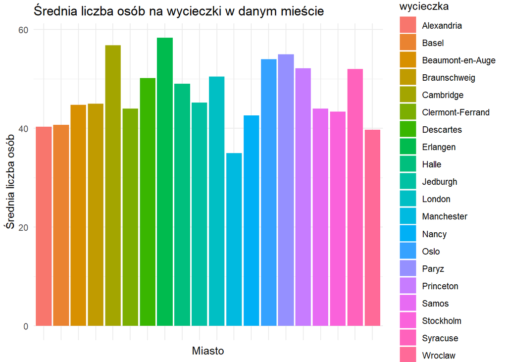